# Standardized effect sizes

Neander M. Heming, Flávio Mota, and Gabriela Alves-Ferreira

2024-10-22

## Contents

- Standardized effect sizes
- Calculating SES
  - Random species generation
  - SES with spatial randomization
  - SES from species trait randomization
- Conclusion
- References

After understanding how the spatial null model algorithms work (`vignette("spatial-null-models")`), let’s see how to create multiple null models and test for the effect size using `SESraster()`.

## Standardized effect size

Standardized effect size (SES) is a measure of the magnitude of the studied effect. It indicates the direction and the degree that the effect departures from the null model. SESraster uses Cohen’s *d* (Cohen 1988), which is measured as the difference between the observed pattern and the average of *n* randomized observations divided by the standard deviation of the randomized observations $SES = (Obs-mean(Null))/sd(Null)$.

## Calculating SES

### Random species generation

First, we will create some random species distributions using the package `terra`.

```r
library(SESraster)
library(terra)
```

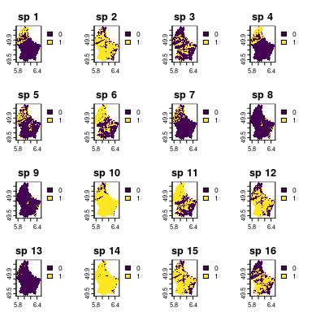

```r
# creating random species distributions
f <- system.file("ex/elev.tif", package="terra")
r <- rast(f)
set.seed(510)
r <- rast(lapply(1:18,
                function(i, r, mn, mx){
                  app(r, function(x, t){
                    sapply(x, function(x, t){
                       x<max(t) & x>min(t)
                    }, t = t)
                  }, t = sample(seq(mn, mx), 2))
                }, r = r, mn = minmax(r)[1]+10, mx = minmax(r)[2]-10))

names(r) <- paste("sp", 1:nlyr(r))
plot(r)
```

With the distributions in hand, we can perform the spatial randomizations.

### SES with spatial randomization

First we need a function that computes the desired metric. The function must work with spatial data. Just to exemplify, we are creating a function to compute the mean of presences and absences (1/0) within each cell. You probably wants to use a more ecologically meaningful function, but here is just an example of use.

```r
appmean <- function(x, ...){
                      terra::app(x, "mean", ...)
}
```

Now, to compute SES, we will compute our desired metric by sending our function `appmean()` to `SESraster()` through `FUN` argument. We also randomize the original data by `species` using the `bootspat_naive()` algorithm and passing the argument `random="species"` through `spat_alg_args`.

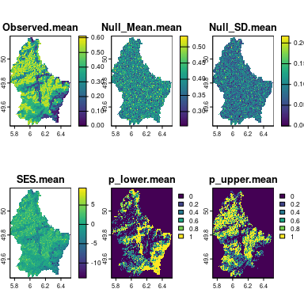

```r
ses.sp <- SESraster(r, FUN = appmean,
                    spat_alg = "bootspat_naive", spat_alg_args = list(random = "species"),
                    aleats = 5)
plot(ses.sp)
```

Compute metric and SES using `bootspat_naive()` and randomize by `site` changing the argument to `random="site"` in `spat_alg_args`.

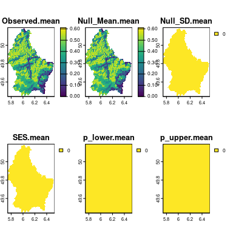

```r
ses.st <- SESraster(r, FUN = appmean,
                    spat_alg = "bootspat_naive", spat_alg_args = list(random = "site"),
                    aleats = 5)
plot(ses.st)
```

#### Passing arguments to `FUN`

It is also possible to send arguments to the function that calculates the desired metric (`FUN`). It can be done by sending a list of arguments through `FUN_args`.

```r
## let's create some missing values for layer/species 1
r2 <- r
set.seed(10)
cellsNA <- terra::spatSample(r2, 30, na.rm = TRUE, cells = TRUE, values = FALSE)
r2[cellsNA][1] <- NA
# plot(r)
set.seed(10)
sesNA <- SESraster(r2, FUN = appmean, FUN_args = list(na.rm = FALSE),
                   spat_alg = "bootspat_naive", spat_alg_args=list(random = "species"),
                   aleats = 5)
head(sesNA[cellsNA])
```

```
#>   Observed.mean Null_Mean.mean Null_SD.mean SES.mean p_lower.mean p_upper.mean
#> 1            NA             NA           NA       NA            0            0
#> 2            NA             NA           NA       NA            0            0
#> 3            NA             NA           NA       NA            0            0
#> 4            NA             NA           NA       NA            0            0
#> 5            NA             NA           NA       NA            0            0
#> 6            NA             NA           NA       NA            0            0
```

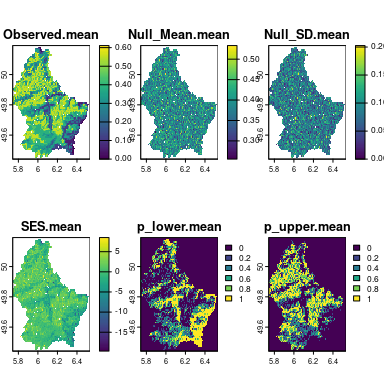

```r
plot(sesNA)
```

Notice that NAs can be ignored by the `appmean()` function by using `FUN_args = list(na.rm = TRUE)`:

```r
set.seed(10)
ses.woNA <- SESraster(r2, FUN = appmean, FUN_args = list(na.rm = TRUE),
                      spat_alg = "bootspat_naive", spat_alg_args=list(random = "species"),
                      aleats = 5)
head(ses.woNA[cellsNA])
```

```
#>   Observed.mean Null_Mean.mean Null_SD.mean   SES.mean p_lower.mean
#> 1    0.11764706      0.3882353   0.08921030 -3.0331502          1.0
#> 2    0.41176471      0.3882353   0.08921030  0.2637522          0.2
#> 3    0.41176471      0.4117647   0.09300817  0.0000000          0.4
#> 4    0.05882353      0.3647059   0.07669650 -3.9882179          1.0
#> 5    0.35294118      0.4000000   0.07669650 -0.6135720          0.6
#> 6    0.52941176      0.4941176   0.08921030  0.3956283          0.2
#>   p_upper.mean
#> 1          0.0
#> 2          0.6
#> 3          0.4
#> 4          0.0
#> 5          0.2
#> 6          0.4
```

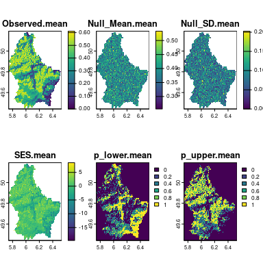

```r
plot(ses.woNA)
```

### SES from species trait randomization

In addition to the spatial randomizations, it is possible to create a null model by randomizing a parameter (i.e. argument) of the metric passed to FUN. This is useful, for example, to randomize a species trait (e.g. branch length) that is used to compute the metric. In the example below the function `appsv()` uses the argument `lyrv` to compute the fictional metric. We also create some fictional values for the trait.

```r
## example with `Fa_alg`
appsv <- function(x, lyrv, na.rm = FALSE, ...){
                      sumw <- function(x, lyrv, na.rm, ...){
                        ifelse(all(is.na(x)), NA,
                               sum(x*lyrv, na.rm=na.rm, ...))
                      }
                      stats::setNames(terra::app(x, sumw, lyrv = lyrv, na.rm=na.rm, ...), "sumw")
}

set.seed(10)
trait  <- sample(100:2000, nlyr(r))
trait
```

```
#>  [1]  590 1772 1453  467 1583  538 1707 1561 1546 1634 1846  443 1394  242 1037
#> [16] 1578 1998 1029
```

In this exapmle, no spatial randomization will be performed, only trait randomization. To select the *trait* to be randomized, pick the desired argument of `FUN_args` using `Fa_sample` and the name of the desired argument (here “lyrv”). Then select a function, here “sample” is used. It is also possible to send arguments to the function in `Fa_alg` through `Fa_alg_args`. It works in the same way that arguments are sent to `FUN` and `spat_alg` through `FUN_args` and `spat_alg_args`.  
In this first example it is performed a trait sampling **without** replacement.

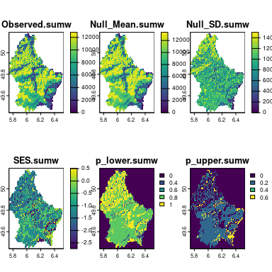

```r
set.seed(10)
ses <- SESraster(r, FUN = appsv,
                 FUN_args = list(lyrv = trait, na.rm = TRUE),
                    Fa_sample = "lyrv",
                    Fa_alg = "sample", Fa_alg_args = list(replace = FALSE),
                    aleats = 5)
plot(ses)
```

In this second example it is performed a trait sampling **with** replacement by passing `replace = TRUE` through `Fa_alg_args`.

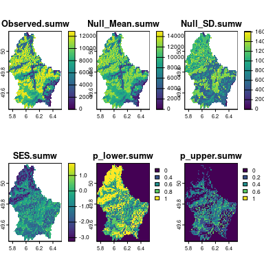

```r
set.seed(10)
ses <- SESraster(r, FUN = appsv,
                 FUN_args = list(lyrv = trait, na.rm = TRUE),
                    Fa_sample = "lyrv",
                    Fa_alg = "sample", Fa_alg_args = list(replace = TRUE),
                    aleats = 5)
plot(ses)
```

## Conclusion

The `SESraster` R package aims to simplify the randomization of raster data and the calculation of standardized effect sizes for spatial data. We hope it is useful to analize the vast amount of raster data generated for the analysis of biogeographycal and macroecological patterns.

## References

Cohen, Jacob. 1988. *Statistical Power Analysis for the Behavioral Sciences*. Academic Press.